# Práctica 2

```python
import Clasificador
import EstrategiaParticionado
from Datos import Datos
from sklearn.model_selection import cross_val_score
from sklearn.neighbors import KNeighborsClassifier
from sklearn.linear_model import LogisticRegression
from plotModel import plotModel
import matplotlib.pyplot as plt
import pandas as pd
```

## Apartado 1 - Vecinos Próximos

### Validación Cruzada (4 particiones) - wdbc.data (datos normalizados)

```python
# Elegimos el conjunto de datos
dataset = Datos('./ConjuntoDatos/wdbc.data')

# Elegimos la estrategia de particionado
estrategia = EstrategiaParticionado.ValidacionCruzada(numero_particiones=4)

# Creamos listas que reuna los resultados
lista_knn_valcruzada_norm_indice = []
lista_knn_valcruzada_norm_media = []
lista_knn_valcruzada_norm_std = []
```

Probamos el conjunto para 1 vecino próximo

```python
# Elegimos el clasificador
clasificador = Clasificador.ClasificadorVecinosProximos(vecinos=1, normalizar=True)

# Calculamos el error y la desviación tipica
error_media, error_std = clasificador.validacion(estrategia, dataset, clasificador)

lista_knn_valcruzada_norm_indice.append(1)
lista_knn_valcruzada_norm_media.append(error_media*100)
lista_knn_valcruzada_norm_std.append(error_std)

print(error_media)
print(error_std)
```

```
0.04395252634689255
0.00920781683560843
```

Probamos el conjunto para 3 vecinos próximos

```python
# Elegimos el clasificador
clasificador = Clasificador.ClasificadorVecinosProximos(vecinos=3, normalizar=True)

# Calculamos el error y la desviación tipica
error_media, error_std = clasificador.validacion(estrategia, dataset, clasificador)

lista_knn_valcruzada_norm_indice.append(3)
lista_knn_valcruzada_norm_media.append(error_media*100)
lista_knn_valcruzada_norm_std.append(error_std)

print(error_media)
print(error_std)
```

```
0.036885649561705904
0.01673201071405617
```

Probamos el conjunto para 5 vecinos próximos

```python
# Elegimos el clasificador
clasificador = Clasificador.ClasificadorVecinosProximos(vecinos=5, normalizar=True)

# Calculamos el error y la desviación tipica
error_media, error_std = clasificador.validacion(estrategia, dataset, clasificador)

lista_knn_valcruzada_norm_indice.append(5)
lista_knn_valcruzada_norm_media.append(error_media*100)
lista_knn_valcruzada_norm_std.append(error_std)

print(error_media)
print(error_std)
```

```
0.038683147838077414
0.00793973321904064
```

Probamos el conjunto para 11 vecinos próximos

```python
# Elegimos el clasificador
clasificador = Clasificador.ClasificadorVecinosProximos(vecinos=11, normalizar=True)

# Calculamos el error y la desviación tipica
error_media, error_std = clasificador.validacion(estrategia, dataset, clasificador)

lista_knn_valcruzada_norm_indice.append(11)
lista_knn_valcruzada_norm_media.append(error_media*100)
lista_knn_valcruzada_norm_std.append(error_std)

print(error_media)
print(error_std)
```

```
0.043940214714862605
0.007692110246507128
```

Probamos el conjunto para 21 vecinos próximos

```python
# Elegimos el clasificador
clasificador = Clasificador.ClasificadorVecinosProximos(vecinos=21, normalizar=True)

# Calculamos el error y la desviación tipica
error_media, error_std = clasificador.validacion(estrategia, dataset, clasificador)

lista_knn_valcruzada_norm_indice.append(21)
lista_knn_valcruzada_norm_media.append(error_media*100)
lista_knn_valcruzada_norm_std.append(error_std)

print(error_media)
print(error_std)
```

```
0.04045602285038905
0.01891789529412814
```

Probamos el conjunto para 51 vecinos próximos

```python
# Elegimos el clasificador
clasificador = Clasificador.ClasificadorVecinosProximos(vecinos=51, normalizar=True)

# Calculamos el error y la desviación tipica
error_media, error_std = clasificador.validacion(estrategia, dataset, clasificador)

lista_knn_valcruzada_norm_indice.append(51)
lista_knn_valcruzada_norm_media.append(error_media*100)
lista_knn_valcruzada_norm_std.append(error_std)

print(error_media)
print(error_std)
```

```
0.05095784497192948
0.009092713306264428
```

### Validación Cruzada (4 particiones) - wdbc.data (datos no normalizados)

```python
# Elegimos el conjunto de datos
dataset = Datos('./ConjuntoDatos/wdbc.data')

# Elegimos la estrategia de particionado
estrategia = EstrategiaParticionado.ValidacionCruzada(numero_particiones=4)

# Creamos listas que reuna los resultados
lista_knn_valcruzada_indice = []
lista_knn_valcruzada_media = []
lista_knn_valcruzada_std = []
```

Probamos el conjunto para 1 vecino próximo

```python
# Elegimos el clasificador
clasificador = Clasificador.ClasificadorVecinosProximos(vecinos=1, normalizar=False)

# Calculamos el error y la desviación tipica
error_media, error_std = clasificador.validacion(estrategia, dataset, clasificador)

lista_knn_valcruzada_indice.append(1)
lista_knn_valcruzada_media.append(error_media*100)
lista_knn_valcruzada_std.append(error_std)

print(error_media)
print(error_std)
```

```
0.0808258642765685
0.007660754125335673
```

Probamos el conjunto para 3 vecinos próximos

```python
# Elegimos el clasificador
clasificador = Clasificador.ClasificadorVecinosProximos(vecinos=3, normalizar=False)

# Calculamos el error y la desviación tipica
error_media, error_std = clasificador.validacion(estrategia, dataset, clasificador)

lista_knn_valcruzada_indice.append(3)
lista_knn_valcruzada_media.append(error_media*100)
lista_knn_valcruzada_std.append(error_std)

print(error_media)
print(error_std)
```

```
0.08786811779769527
0.015313982746123915
```

Probamos el conjunto para 5 vecinos próximos

```python
# Elegimos el clasificador
clasificador = Clasificador.ClasificadorVecinosProximos(vecinos=5, normalizar=False)

# Calculamos el error y la desviación tipica
error_media, error_std = clasificador.validacion(estrategia, dataset, clasificador)

lista_knn_valcruzada_indice.append(5)
lista_knn_valcruzada_media.append(error_media*100)
lista_knn_valcruzada_std.append(error_std)

print(error_media)
print(error_std)
```

```
0.07731704914803506
0.013098141587011863
```

Probamos el conjunto para 11 vecinos próximos

```python
# Elegimos el clasificador
clasificador = Clasificador.ClasificadorVecinosProximos(vecinos=11, normalizar=False)

# Calculamos el error y la desviación tipica
error_media, error_std = clasificador.validacion(estrategia, dataset, clasificador)

lista_knn_valcruzada_indice.append(11)
lista_knn_valcruzada_media.append(error_media*100)
lista_knn_valcruzada_std.append(error_std)

print(error_media)
print(error_std)
```

```
0.07203535900718999
0.007437479225488604
```

Probamos el conjunto para 21 vecinos próximos

```python
# Elegimos el clasificador
clasificador = Clasificador.ClasificadorVecinosProximos(vecinos=21, normalizar=False)

# Calculamos el error y la desviación tipica
error_media, error_std = clasificador.validacion(estrategia, dataset, clasificador)

lista_knn_valcruzada_indice.append(21)
lista_knn_valcruzada_media.append(error_media*100)
lista_knn_valcruzada_std.append(error_std)

print(error_media)
print(error_std)
```

```
0.07203535900718999
0.020061641005170296
```

Probamos el conjunto para 51 vecinos próximos

```python
# Elegimos el clasificador
clasificador = Clasificador.ClasificadorVecinosProximos(vecinos=51, normalizar=False)

# Calculamos el error y la desviación tipica
error_media, error_std = clasificador.validacion(estrategia, dataset, clasificador)

lista_knn_valcruzada_indice.append(51)
lista_knn_valcruzada_media.append(error_media*100)
lista_knn_valcruzada_std.append(error_std)

print(error_media)
print(error_std)
```

```
0.08791736432581501
0.025254980753139027
```

### Validación Simple (50-50) - online_shoppers.data (datos normalizados)

### Importante:

Solo probaremos online_shoppers.data con datos normalizados ya que la ejecución del clasificador por cada conjunto de datos online_shoppers.data tarda muchísimo.

```python
# Elegimos el conjunto de datos
dataset = Datos('./ConjuntoDatos/online_shoppers.data')

# Elegimos la estrategia de particionado
estrategia = EstrategiaParticionado.ValidacionSimple(porcentaje_particion=50)

# Creamos listas que reuna los resultados
lista_knn_valsimple_indice = []
lista_knn_valsimple_media = []
```

Probamos el conjunto para 11 vecinos próximos

```python
# Elegimos el clasificador
clasificador = Clasificador.ClasificadorVecinosProximos(vecinos=11)

# Calculamos el error y la desviación tipica
error_media, error_std = clasificador.validacion(estrategia, dataset, clasificador)

lista_knn_valsimple_indice.append(11)
lista_knn_valsimple_media.append(error_media*100)

print(error_media)
print(error_std)
```

```
0.12003244120032441
0
```

### Colección de Resultados

```python
print("-- Conjunto de datos wdbc.data --")
print("Resultados para KNN con Validación Cruzada y datos normalizados:")
dataFrame = zip(lista_knn_valcruzada_norm_indice, lista_knn_valcruzada_norm_media, lista_knn_valcruzada_norm_std)
tabla1 = pd.DataFrame(dataFrame, columns=["Num Vecinos", "Tasa error (%)", "Tasa std"]).style.hide_index()
display(tabla1)

print("Resultados para KNN con Validación Cruzada y datos NO normalizados:")
dataFrame = zip(lista_knn_valcruzada_indice, lista_knn_valcruzada_media, lista_knn_valcruzada_std)
tabla2 = pd.DataFrame(dataFrame, columns=["Num Vecinos", "Tasa error (%)", "Tasa std"]).style.hide_index()
display(tabla2)

print("-- Conjunto de datos online_shoppers.data --")
print("Resultados para KNN con Validación Simple:")
dataFrame = zip(lista_knn_valsimple_indice, lista_knn_valsimple_media)
tabla3 = pd.DataFrame(dataFrame, columns=["Num Vecinos", "Tasa error (%)"]).style.hide_index()
display(tabla3)
```

```
-- Conjunto de datos wdbc.data --
Resultados para KNN con Validación Cruzada y datos normalizados:
```

| Num Vecinos | Tasa error (%) | Tasa std |
| --- | --- | --- |
| 1 | 4.39525 | 0.00920782 |
| 3 | 3.68856 | 0.016732 |
| 5 | 3.86831 | 0.00793973 |
| 11 | 4.39402 | 0.00769211 |
| 21 | 4.0456 | 0.0189179 |
| 51 | 5.09578 | 0.00909271 |

```
Resultados para KNN con Validación Cruzada y datos NO normalizados:
```

| Num Vecinos | Tasa error (%) | Tasa std |
| --- | --- | --- |
| 1 | 8.08259 | 0.00766075 |
| 3 | 8.78681 | 0.015314 |
| 5 | 7.7317 | 0.0130981 |
| 11 | 7.20354 | 0.00743748 |
| 21 | 7.20354 | 0.0200616 |
| 51 | 8.79174 | 0.025255 |

```
-- Conjunto de datos online_shoppers.data --
Resultados para KNN con Validación Simple:
```

| Num Vecinos | Tasa error (%) |
| --- | --- |
| 11 | 12.0032 |

## Apartado 2 - Regresión Logística

### Validación Cruzada (4 particiones) - wdbc.data

```python
# Elegimos el conjunto de datos
dataset = Datos('./ConjuntoDatos/wdbc.data')

# Elegimos la estrategia de particionado
estrategia = EstrategiaParticionado.ValidacionCruzada(numero_particiones=4)

# Creamos listas que reuna los resultados
lista_rl_valcruzada_fa = []
lista_rl_valcruzada_epocas = []
lista_rl_valcruzada_media = []
lista_rl_valcruzada_std = []
```

Probamos el clasificador con una constante de aprendizaje de 0.1 y 10 épocas:

```python
# Elegimos el clasificador
clasificador = Clasificador.ClasificadorRegresionLogistica(aprendizaje=0.1, epocas=10)

# Calculamos el error y la desviación tipica
error_media, error_std = clasificador.validacion(estrategia, dataset, clasificador)

lista_rl_valcruzada_fa.append(0.1)
lista_rl_valcruzada_epocas.append(10)
lista_rl_valcruzada_media.append(error_media*100)
lista_rl_valcruzada_std.append(error_std)

print(error_media)
print(error_std)
```

```
0.0368856495617059
0.01745728644042944
```

Probamos el clasificador con una constante de aprendizaje de 0.1 y 50 épocas:

```python
# Elegimos el clasificador
clasificador = Clasificador.ClasificadorRegresionLogistica(aprendizaje=0.1, epocas=50)

# Calculamos el error y la desviación tipica
error_media, error_std = clasificador.validacion(estrategia, dataset, clasificador)

lista_rl_valcruzada_fa.append(0.1)
lista_rl_valcruzada_epocas.append(50)
lista_rl_valcruzada_media.append(error_media*100)
lista_rl_valcruzada_std.append(error_std)

print(error_media)
print(error_std)
```

```
0.03510046291736433
0.019762110024853646
```

Probamos el clasificador con una constante de aprendizaje de 0.1 y 100 épocas:

```python
# Elegimos el clasificador
clasificador = Clasificador.ClasificadorRegresionLogistica(aprendizaje=0.1, epocas=100)

# Calculamos el error y la desviación tipica
error_media, error_std = clasificador.validacion(estrategia, dataset, clasificador)

lista_rl_valcruzada_fa.append(0.1)
lista_rl_valcruzada_epocas.append(100)
lista_rl_valcruzada_media.append(error_media*100)
lista_rl_valcruzada_std.append(error_std)

print(error_media)
print(error_std)
```

```
0.04736284841918645
0.03579405183056418
```

Probamos el clasificador con una constante de aprendizaje de 0.5 y 10 épocas:

```python
# Elegimos el clasificador
clasificador = Clasificador.ClasificadorRegresionLogistica(aprendizaje=0.5, epocas=10)

# Calculamos el error y la desviación tipica
error_media, error_std = clasificador.validacion(estrategia, dataset, clasificador)

lista_rl_valcruzada_fa.append(0.5)
lista_rl_valcruzada_epocas.append(10)
lista_rl_valcruzada_media.append(error_media*100)
lista_rl_valcruzada_std.append(error_std)

print(error_media)
print(error_std)
```

```
0.056227223480744604
0.016469351663972804
```

Probamos el clasificador con una constante de aprendizaje de 0.5 y 50 épocas:

```python
# Elegimos el clasificador
clasificador = Clasificador.ClasificadorRegresionLogistica(aprendizaje=0.5, epocas=50)

# Calculamos el error y la desviación tipica
error_media, error_std = clasificador.validacion(estrategia, dataset, clasificador)

lista_rl_valcruzada_fa.append(0.5)
lista_rl_valcruzada_epocas.append(50)
lista_rl_valcruzada_media.append(error_media*100)
lista_rl_valcruzada_std.append(error_std)

print(error_media)
print(error_std)
```

```
0.04046833448241899
0.0160800425046914
```

Probamos el clasificador con una constante de aprendizaje de 0.5 y 100 épocas:

```python
# Elegimos el clasificador
clasificador = Clasificador.ClasificadorRegresionLogistica(aprendizaje=0.5, epocas=100)

# Calculamos el error y la desviación tipica
error_media, error_std = clasificador.validacion(estrategia, dataset, clasificador)

lista_rl_valcruzada_fa.append(0.5)
lista_rl_valcruzada_epocas.append(100)
lista_rl_valcruzada_media.append(error_media*100)
lista_rl_valcruzada_std.append(error_std)

print(error_media)
print(error_std)
```

```
0.03516202107751404
0.017973802157488814
```

Probamos el clasificador con una constante de aprendizaje de 1 y 10 épocas:

```python
# Elegimos el clasificador
clasificador = Clasificador.ClasificadorRegresionLogistica(aprendizaje=1, epocas=10)

# Calculamos el error y la desviación tipica
error_media, error_std = clasificador.validacion(estrategia, dataset, clasificador)

lista_rl_valcruzada_fa.append(1)
lista_rl_valcruzada_epocas.append(10)
lista_rl_valcruzada_media.append(error_media*100)
lista_rl_valcruzada_std.append(error_std)

print(error_media)
print(error_std)
```

```
0.07739091894021471
0.03563493373086132
```

Probamos el clasificador con una constante de aprendizaje de 1 y 50 épocas:

```python
# Elegimos el clasificador
clasificador = Clasificador.ClasificadorRegresionLogistica(aprendizaje=1, epocas=50)

# Calculamos el error y la desviación tipica
error_media, error_std = clasificador.validacion(estrategia, dataset, clasificador)

lista_rl_valcruzada_fa.append(1)
lista_rl_valcruzada_epocas.append(50)
lista_rl_valcruzada_media.append(error_media*100)
lista_rl_valcruzada_std.append(error_std)

print(error_media)
print(error_std)
```

```
0.056202600216684724
0.012957985400566393
```

Probamos el clasificador con una constante de aprendizaje de 1 y 100 épocas:

```python
# Elegimos el clasificador
clasificador = Clasificador.ClasificadorRegresionLogistica(aprendizaje=1, epocas=100)

# Calculamos el error y la desviación tipica
error_media, error_std = clasificador.validacion(estrategia, dataset, clasificador)

lista_rl_valcruzada_fa.append(1)
lista_rl_valcruzada_epocas.append(10)
lista_rl_valcruzada_media.append(error_media*100)
lista_rl_valcruzada_std.append(error_std)

print(error_media)
print(error_std)
```

```
0.05097015660395942
0.016049646754983802
```

### Validación Simple (50-50) - online_shoppers.data

```python
# Elegimos el conjunto de datos
dataset = Datos('./ConjuntoDatos/online_shoppers.data')

# Elegimos la estrategia de particionado
estrategia = EstrategiaParticionado.ValidacionSimple(porcentaje_particion=50)

# Creamos listas que reuna los resultados
lista_rl_valsimple_fa = []
lista_rl_valsimple_epocas = []
lista_rl_valsimple_media = []
```

Probamos el clasificador con una constante de aprendizaje de 0.1 y 10 época:

```python
# Elegimos el clasificador
clasificador = Clasificador.ClasificadorRegresionLogistica(aprendizaje=0.1, epocas=10)

# Calculamos el error y la desviación tipica
error_media, error_std = clasificador.validacion(estrategia, dataset, clasificador)

lista_rl_valsimple_fa.append(0.1)
lista_rl_valsimple_epocas.append(10)
lista_rl_valsimple_media.append(error_media*100)

print(error_media)
print(error_std)
```

```
0.2186536901865369
0
```

### Colección de Resultados

```python
print("-- Conjunto de datos wdbc.data --")
print("Resultados para Regresión Logística con Validación Cruzadas:")
dataFrame = zip(lista_rl_valcruzada_fa, lista_rl_valcruzada_epocas, lista_rl_valcruzada_media, lista_rl_valcruzada_std)
tabla4 = pd.DataFrame(dataFrame, columns=["Factor de Aprendizaje", "Num Epocas" , "Tasa error (%)", "Tasa std"]).style.hide_index()
display(tabla4)


print("-- Conjunto de datos online_shoppers.data --")
print("Resultados para Regresión Logística con Validación Simple:")
dataFrame = zip(lista_rl_valsimple_fa, lista_rl_valsimple_epocas, lista_rl_valsimple_media)
tabla5 = pd.DataFrame(dataFrame, columns=["Factor de Aprendizaje", "Num Epocas" , "Tasa error (%)"]).style.hide_index()
display(tabla5)
```

```
-- Conjunto de datos wdbc.data --
Resultados para Regresión Logística con Validación Cruzadas:
```

| Factor de Aprendizaje | Num Epocas | Tasa error (%) | Tasa std |
| --- | --- | --- | --- |
| 0.1 | 10 | 3.68856 | 0.0174573 |
| 0.1 | 50 | 3.51005 | 0.0197621 |
| 0.1 | 100 | 4.73628 | 0.0357941 |
| 0.5 | 10 | 5.62272 | 0.0164694 |
| 0.5 | 50 | 4.04683 | 0.01608 |
| 0.5 | 100 | 3.5162 | 0.0179738 |
| 1 | 10 | 7.73909 | 0.0356349 |
| 1 | 50 | 5.62026 | 0.012958 |
| 1 | 10 | 5.09702 | 0.0160496 |

```
-- Conjunto de datos online_shoppers.data --
Resultados para Regresión Logística con Validación Simple:
```

| Factor de Aprendizaje | Num Epocas | Tasa error (%) |
| --- | --- | --- |
| 0.1 | 10 | 21.8654 |

### Comparación de los Resultados de RL con KNN

```python
print("-- Conjunto de datos wdbc.data --")
print("Resultados para KNN con Validación Cruzada y datos normalizados:")
display(tabla1)
print("Resultados para Regresión Logística con Validación Cruzadas:")
display(tabla4)
print("-- Conjunto de datos online_shoppers.data --")
print("Resultados para KNN con Validación Simple:")
display(tabla3)
print("Resultados para Regresión Logística con Validación Simple:")
display(tabla5)
```

```
-- Conjunto de datos wdbc.data --
Resultados para KNN con Validación Cruzada y datos normalizados:
```

| Num Vecinos | Tasa error (%) | Tasa std |
| --- | --- | --- |
| 1 | 4.39525 | 0.00920782 |
| 3 | 3.68856 | 0.016732 |
| 5 | 3.86831 | 0.00793973 |
| 11 | 4.39402 | 0.00769211 |
| 21 | 4.0456 | 0.0189179 |
| 51 | 5.09578 | 0.00909271 |

```
Resultados para Regresión Logística con Validación Cruzadas:
```

| Factor de Aprendizaje | Num Epocas | Tasa error (%) | Tasa std |
| --- | --- | --- | --- |
| 0.1 | 10 | 3.68856 | 0.0174573 |
| 0.1 | 50 | 3.51005 | 0.0197621 |
| 0.1 | 100 | 4.73628 | 0.0357941 |
| 0.5 | 10 | 5.62272 | 0.0164694 |
| 0.5 | 50 | 4.04683 | 0.01608 |
| 0.5 | 100 | 3.5162 | 0.0179738 |
| 1 | 10 | 7.73909 | 0.0356349 |
| 1 | 50 | 5.62026 | 0.012958 |
| 1 | 10 | 5.09702 | 0.0160496 |

```
-- Conjunto de datos online_shoppers.data --
Resultados para KNN con Validación Simple:
```

| Num Vecinos | Tasa error (%) |
| --- | --- |
| 11 | 12.0032 |

```
Resultados para Regresión Logística con Validación Simple:
```

| Factor de Aprendizaje | Num Epocas | Tasa error (%) |
| --- | --- | --- |
| 0.1 | 10 | 21.8654 |

Para el conjunto de datos de "wdbc.data" se obtienen mejores resultados en Regresión Logística si el factor de aprendizaje y el número de épocas son bajos. Pero los resultados son muy parecidos entre ambos. Los resultados obtenidos son muy buenos resultados, son unas tasas de error muy bajas.

## Apartado 3 - Algoritmos de Scikit-Learn y comparación de resultados

### VECINOS PRÓXIMOS

```python
# Elegimos el conjunto de datos
dataset = Datos('./ConjuntoDatos/wdbc.data')

valores_train = dataset.datos[:, :-1]
valores_test = dataset.datos[:, -1]

# Creamos listas que reuna los resultados
lista_knn_sklearn_indices = []
lista_knn_sklearn_error = []
lista_knn_sklearn_std = []
```

Probamos el conjunto para 1 vecino próximo

```python
clasificador_knn_sklearn = KNeighborsClassifier(n_neighbors=1, p=2)
score = cross_val_score(clasificador_knn_sklearn, valores_train, valores_test, cv=4)
media_invertida = score.mean()
media = 1 - media_invertida
desv = score.std()

lista_knn_sklearn_indices.append(1)
lista_knn_sklearn_error.append(media*100)
lista_knn_sklearn_std.append(desv)

print(media)
print(desv)
```

```
0.08957943464985718
0.01715988894793592
```

Probamos el conjunto para 3 vecinos próximos

```python
clasificador_knn_sklearn = KNeighborsClassifier(n_neighbors=3, p=2)
score = cross_val_score(clasificador_knn_sklearn, valores_train, valores_test, cv=4)
media_invertida = score.mean()
media = 1 - media_invertida
desv = score.std()

lista_knn_sklearn_indices.append(3)
lista_knn_sklearn_error.append(media*100)
lista_knn_sklearn_std.append(desv)

print(media)
print(desv)
```

```
0.07374667585935202
0.027224167140619968
```

Probamos el conjunto para 5 vecinos próximos

```python
clasificador_knn_sklearn = KNeighborsClassifier(n_neighbors=5, p=2)
score = cross_val_score(clasificador_knn_sklearn, valores_train, valores_test, cv=4)
media_invertida = score.mean()
media = 1 - media_invertida
desv = score.std()

lista_knn_sklearn_indices.append(5)
lista_knn_sklearn_error.append(media*100)
lista_knn_sklearn_std.append(desv)

print(media)
print(desv)
```

```
0.0720107357431301
0.01725816367595375
```

Probamos el conjunto para 11 vecinos próximos

```python
clasificador_knn_sklearn = KNeighborsClassifier(n_neighbors=11, p=2)
score = cross_val_score(clasificador_knn_sklearn, valores_train, valores_test, cv=4)
media_invertida = score.mean()
media = 1 - media_invertida
desv = score.std()

lista_knn_sklearn_indices.append(11)
lista_knn_sklearn_error.append(media*100)
lista_knn_sklearn_std.append(desv)

print(media)
print(desv)
```

```
0.06671673397025513
0.023317837791204627
```

Probamos el conjunto para 21 vecinos próximos

```python
clasificador_knn_sklearn = KNeighborsClassifier(n_neighbors=21, p=2)
score = cross_val_score(clasificador_knn_sklearn, valores_train, valores_test, cv=4)
media_invertida = score.mean()
media = 1 - media_invertida
desv = score.std()

lista_knn_sklearn_indices.append(21)
lista_knn_sklearn_error.append(media*100)
lista_knn_sklearn_std.append(desv)

print(media)
print(desv)
```

```
0.07022554909878864
0.02555346776287912
```

Probamos el conjunto para 51 vecinos próximos

```python
clasificador_knn_sklearn = KNeighborsClassifier(n_neighbors=51, p=2)
score = cross_val_score(clasificador_knn_sklearn, valores_train, valores_test, cv=4)
media_invertida = score.mean()
media = 1 - media_invertida
desv = score.std()

lista_knn_sklearn_indices.append(51)
lista_knn_sklearn_error.append(media*100)
lista_knn_sklearn_std.append(desv)

print(media)
print(desv)
```

```
0.08427312124495223
0.029068623616263674
```

### Comparación de KNN con Scikit-Learn KNN

```python
dataFrame = zip(lista_knn_sklearn_indices, lista_knn_sklearn_error, lista_knn_sklearn_std)
tabla6 = pd.DataFrame(dataFrame, columns=["Num Vecinos", "Tasa error (%)", "Tasa std"]).style.hide_index()
print("Tabla Scikit-Learn KNN")
display(tabla6)
print("Tabla de nuestro clasificador KNN")
display(tabla1)
```

```
Tabla Scikit-Learn KNN
```

| Num Vecinos | Tasa error (%) | Tasa std |
| --- | --- | --- |
| 1 | 8.95794 | 0.0171599 |
| 3 | 7.37467 | 0.0272242 |
| 5 | 7.20107 | 0.0172582 |
| 11 | 6.67167 | 0.0233178 |
| 21 | 7.02255 | 0.0255535 |
| 51 | 8.42731 | 0.0290686 |

```
Tabla de nuestro clasificador KNN
```

| Num Vecinos | Tasa error (%) | Tasa std |
| --- | --- | --- |
| 1 | 4.39525 | 0.00920782 |
| 3 | 3.68856 | 0.016732 |
| 5 | 3.86831 | 0.00793973 |
| 11 | 4.39402 | 0.00769211 |
| 21 | 4.0456 | 0.0189179 |
| 51 | 5.09578 | 0.00909271 |

Podemos ver que los resultados obtenidos con el clasificador de la biblioteca Scikit-Learn son también unos buenos resultados, aunque hemos logrado mejorar la eficacia con nuestra implementación

### REGRESIÓN LOGÍSTICA

```python
# Elegimos el conjunto de datos
dataset = Datos('./ConjuntoDatos/wdbc.data')

valores_train = dataset.datos[:, :-1]
valores_test = dataset.datos[:, -1]

# Creamos listas que reuna los resultados
lista_rl_sklearn_epocas = []
lista_rl_sklearn_error = []
lista_rl_sklearn_std = []
```

Probamos el conjunto para 10 épocas

```python
clasificador_rl_sklearn = LogisticRegression(max_iter=10)
score = cross_val_score(clasificador_knn_sklearn, valores_train, valores_test, cv=4)
media = score.mean()
invertido = 1 - media
desv = score.std()

lista_rl_sklearn_epocas.append(10)
lista_rl_sklearn_error.append(media*100)
lista_rl_sklearn_std.append(desv)

print(media)
print(desv)
```

```
0.9157268787550478
0.029068623616263674
```

Probamos el conjunto para 50 épocas

```python
clasificador_rl_sklearn = LogisticRegression(max_iter=50)
score = cross_val_score(clasificador_knn_sklearn, valores_train, valores_test, cv=4)
media = score.mean()
invertido = 1 - media
desv = score.std()

lista_rl_sklearn_epocas.append(50)
lista_rl_sklearn_error.append(media*100)
lista_rl_sklearn_std.append(desv)

print(media)
print(desv)
```

```
0.9157268787550478
0.029068623616263674
```

```python
clasificador_rl_sklearn = LogisticRegression(max_iter=100)
score = cross_val_score(clasificador_knn_sklearn, valores_train, valores_test, cv=4)
media = score.mean()
invertido = 1 - media
desv = score.std()

lista_rl_sklearn_epocas.append(100)
lista_rl_sklearn_error.append(media*100)
lista_rl_sklearn_std.append(desv)

print(media)
print(desv)
```

```
0.9157268787550478
0.029068623616263674
```

### Comparación de RL con Scikit-Learn RL

```python
dataFrame = zip(lista_rl_sklearn_epocas, lista_knn_sklearn_error, lista_knn_sklearn_std)
tabla7 = pd.DataFrame(dataFrame, columns=["Num Épocas", "Tasa error (%)", "Tasa std"]).style.hide_index()
print("Tabla Scikit-Learn RL")
display(tabla7)
print("Tabla de nuestro clasificador RL")
display(tabla4)
```

```
Tabla Scikit-Learn RL
```

| Num Épocas | Tasa error (%) | Tasa std |
| --- | --- | --- |
| 10 | 8.95794 | 0.0171599 |
| 50 | 7.37467 | 0.0272242 |
| 100 | 7.20107 | 0.0172582 |

```
Tabla de nuestro clasificador RL
```

| Factor de Aprendizaje | Num Epocas | Tasa error (%) | Tasa std |
| --- | --- | --- | --- |
| 0.1 | 10 | 3.68856 | 0.0174573 |
| 0.1 | 50 | 3.51005 | 0.0197621 |
| 0.1 | 100 | 4.73628 | 0.0357941 |
| 0.5 | 10 | 5.62272 | 0.0164694 |
| 0.5 | 50 | 4.04683 | 0.01608 |
| 0.5 | 100 | 3.5162 | 0.0179738 |
| 1 | 10 | 7.73909 | 0.0356349 |
| 1 | 50 | 5.62026 | 0.012958 |
| 1 | 10 | 5.09702 | 0.0160496 |

### Conjunto de datos "example1.data"

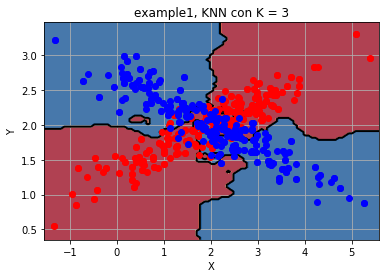

```python
# Elegimos el conjunto de datos
dataset = Datos('./ConjuntoDatos/example1.data')

# Elegimos la estrategia de particionado
# estrategia = EstrategiaParticionado.ValidacionSimple(porcentaje_particion=50)
estrategia = EstrategiaParticionado.ValidacionCruzada(numero_particiones=4)

# Elegimos el clasificador
clasificador = Clasificador.ClasificadorVecinosProximos(vecinos=3, normalizar=True)
# clasificador = Clasificador.ClasificadorRegresionLogistica(aprendizaje=0.5, epocas=10)

# Calculamos el error y la desviación tipica
error_media, error_std = clasificador.validacion(estrategia, dataset, clasificador)

ii=estrategia.particiones[-1].indicesTrain

plotModel(dataset.datos[ii,0],dataset.datos[ii,1],dataset.datos[ii,-1]!=0,clasificador,"example1, KNN con K = 3",dataset.diccionarios)

plt.plot(dataset.datos[dataset.datos[:,-1]==0,0],dataset.datos[dataset.datos[:,-1]==0,1],'ro')
plt.plot(dataset.datos[dataset.datos[:,-1]==1,0],dataset.datos[dataset.datos[:,-1]==1,1],'bo')
plt.show()
```

Como podemos observar, el modelo clasifica correctamente las esquinas, ya que no existen puntos de distintas clases en estas. A medida que nos vamos acercando al centro, el modelo empieza a fallar debido a la variacion de clases en el conjunto de puntos del centro.

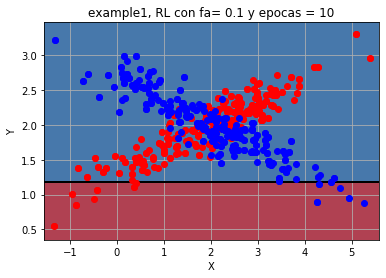

```python
# Elegimos el conjunto de datos
dataset = Datos('./ConjuntoDatos/example1.data')

# Elegimos la estrategia de particionado
# estrategia = EstrategiaParticionado.ValidacionSimple(porcentaje_particion=50)
estrategia = EstrategiaParticionado.ValidacionCruzada(numero_particiones=4)

# Elegimos el clasificador
# clasificador = Clasificador.ClasificadorVecinosProximos(vecinos=3, normalizar=True)
clasificador = Clasificador.ClasificadorRegresionLogistica(aprendizaje=0.1, epocas=10)

# Calculamos el error y la desviación tipica
error_media, error_std = clasificador.validacion(estrategia, dataset, clasificador)

ii=estrategia.particiones[-1].indicesTrain

plotModel(dataset.datos[ii,0],dataset.datos[ii,1],dataset.datos[ii,-1]!=0,clasificador,"example1, RL con fa= 0.1 y epocas = 10",dataset.diccionarios)

plt.plot(dataset.datos[dataset.datos[:,-1]==0,0],dataset.datos[dataset.datos[:,-1]==0,1],'ro')
plt.plot(dataset.datos[dataset.datos[:,-1]==1,0],dataset.datos[dataset.datos[:,-1]==1,1],'bo')
plt.show()
```

Debido a la distribución de los datos en este ejemplo, el clasificador no es capaz de clasificar con mucha precisión. Obtiene unos buenos resultados para uno de los dos conjuntos, pero falla demasiado para el otro.

### Conjunto de datos "example2.data"

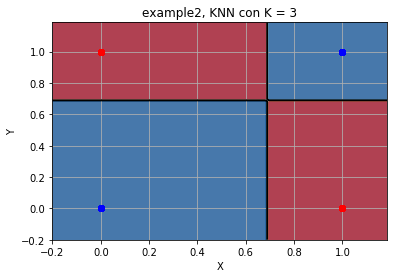

```python
# Elegimos el conjunto de datos
dataset = Datos('./ConjuntoDatos/example2.data')

# Elegimos la estrategia de particionado
# estrategia = EstrategiaParticionado.ValidacionSimple(porcentaje_particion=50)
estrategia = EstrategiaParticionado.ValidacionCruzada(numero_particiones=4)

# Elegimos el clasificador
clasificador = Clasificador.ClasificadorVecinosProximos(vecinos=3, normalizar=True)
# clasificador = Clasificador.ClasificadorRegresionLogistica(aprendizaje=0.5, epocas=10)

# Calculamos el error y la desviación tipica
error_media, error_std = clasificador.validacion(estrategia, dataset, clasificador)

ii=estrategia.particiones[-1].indicesTrain

plotModel(dataset.datos[ii,0],dataset.datos[ii,1],dataset.datos[ii,-1]!=0,clasificador,"example2, KNN con K = 3",dataset.diccionarios)

plt.plot(dataset.datos[dataset.datos[:,-1]==0,0],dataset.datos[dataset.datos[:,-1]==0,1],'ro')
plt.plot(dataset.datos[dataset.datos[:,-1]==1,0],dataset.datos[dataset.datos[:,-1]==1,1],'bo')
plt.show()
```

El clasificador es capaz de clasificar correctamente los 4 puntos. Es un ejemplo muy sencillo de clasificar para Vecinos Próximos

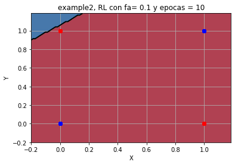

```python
# Elegimos el conjunto de datos
dataset = Datos('./ConjuntoDatos/example2.data')

# Elegimos la estrategia de particionado
# estrategia = EstrategiaParticionado.ValidacionSimple(porcentaje_particion=50)
estrategia = EstrategiaParticionado.ValidacionCruzada(numero_particiones=4)

# Elegimos el clasificador
# clasificador = Clasificador.ClasificadorVecinosProximos(vecinos=3, normalizar=True)
clasificador = Clasificador.ClasificadorRegresionLogistica(aprendizaje=0.1, epocas=10)

# Calculamos el error y la desviación tipica
error_media, error_std = clasificador.validacion(estrategia, dataset, clasificador)

ii=estrategia.particiones[-1].indicesTrain

plotModel(dataset.datos[ii,0],dataset.datos[ii,1],dataset.datos[ii,-1]!=0,clasificador,"example2, RL con fa= 0.1 y epocas = 10",dataset.diccionarios)

plt.plot(dataset.datos[dataset.datos[:,-1]==0,0],dataset.datos[dataset.datos[:,-1]==0,1],'ro')
plt.plot(dataset.datos[dataset.datos[:,-1]==1,0],dataset.datos[dataset.datos[:,-1]==1,1],'bo')
plt.show()
```

Al estar los puntos de la misma clase en las esquinas opuestas, el clasificador no puede crear una frontera que sea capaz de clasificarlos.

### Conjunto de datos "example3.data"

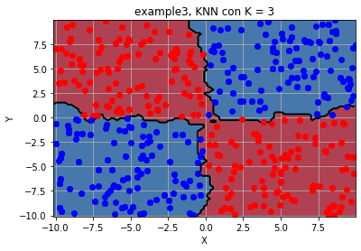

```python
# Elegimos el conjunto de datos
dataset = Datos('./ConjuntoDatos/example3.data')

# Elegimos la estrategia de particionado
# estrategia = EstrategiaParticionado.ValidacionSimple(porcentaje_particion=50)
estrategia = EstrategiaParticionado.ValidacionCruzada(numero_particiones=4)

# Elegimos el clasificador
clasificador = Clasificador.ClasificadorVecinosProximos(vecinos=3, normalizar=True)
# clasificador = Clasificador.ClasificadorRegresionLogistica(aprendizaje=0.5, epocas=10)

# Calculamos el error y la desviación tipica
error_media, error_std = clasificador.validacion(estrategia, dataset, clasificador)

ii=estrategia.particiones[-1].indicesTrain

plotModel(dataset.datos[ii,0],dataset.datos[ii,1],dataset.datos[ii,-1]!=0,clasificador,"example3, KNN con K = 3",dataset.diccionarios)

plt.plot(dataset.datos[dataset.datos[:,-1]==0,0],dataset.datos[dataset.datos[:,-1]==0,1],'ro')
plt.plot(dataset.datos[dataset.datos[:,-1]==1,0],dataset.datos[dataset.datos[:,-1]==1,1],'bo')
plt.show()
```

Podemos observar que el clasificador es capaz de clasificar casi a la perfección, fallando en las fronteras creadas debido a la densidad de puntos de estas.

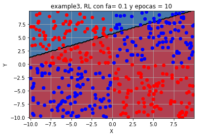

```python
# Elegimos el conjunto de datos
dataset = Datos('./ConjuntoDatos/example3.data')

# Elegimos la estrategia de particionado
# estrategia = EstrategiaParticionado.ValidacionSimple(porcentaje_particion=50)
estrategia = EstrategiaParticionado.ValidacionCruzada(numero_particiones=4)

# Elegimos el clasificador
# clasificador = Clasificador.ClasificadorVecinosProximos(vecinos=3, normalizar=True)
clasificador = Clasificador.ClasificadorRegresionLogistica(aprendizaje=0.1, epocas=10)

# Calculamos el error y la desviación tipica
error_media, error_std = clasificador.validacion(estrategia, dataset, clasificador)

ii=estrategia.particiones[-1].indicesTrain

plotModel(dataset.datos[ii,0],dataset.datos[ii,1],dataset.datos[ii,-1]!=0,clasificador,"example3, RL con fa= 0.1 y epocas = 10",dataset.diccionarios)

plt.plot(dataset.datos[dataset.datos[:,-1]==0,0],dataset.datos[dataset.datos[:,-1]==0,1],'ro')
plt.plot(dataset.datos[dataset.datos[:,-1]==1,0],dataset.datos[dataset.datos[:,-1]==1,1],'bo')
plt.show()
```

Como se trata de otro conjunto con datos cuyos puntos están distribuidos en esquinas opuestas, Regresión logística sigue sin ser capaz de ofrecer una frontera útil. Realiza la frontera que más puntos recoge de una de las dos clases.

#### Conjunto de datos "example4.data"

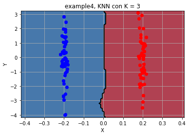

```python
# Elegimos el conjunto de datos
dataset = Datos('./ConjuntoDatos/example4.data')

# Elegimos la estrategia de particionado
# estrategia = EstrategiaParticionado.ValidacionSimple(porcentaje_particion=50)
estrategia = EstrategiaParticionado.ValidacionCruzada(numero_particiones=4)

# Elegimos el clasificador
clasificador = Clasificador.ClasificadorVecinosProximos(vecinos=3, normalizar=True)
# clasificador = Clasificador.ClasificadorRegresionLogistica(aprendizaje=0.5, epocas=10)

# Calculamos el error y la desviación tipica
error_media, error_std = clasificador.validacion(estrategia, dataset, clasificador)

ii=estrategia.particiones[-1].indicesTrain

plotModel(dataset.datos[ii,0],dataset.datos[ii,1],dataset.datos[ii,-1]!=0,clasificador,"example4, KNN con K = 3",dataset.diccionarios)

plt.plot(dataset.datos[dataset.datos[:,-1]==0,0],dataset.datos[dataset.datos[:,-1]==0,1],'ro')
plt.plot(dataset.datos[dataset.datos[:,-1]==1,0],dataset.datos[dataset.datos[:,-1]==1,1],'bo')
plt.show()
```

Al estar las clases separadas, KNN es capaz de clasificar con completa facilidad.

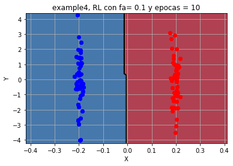

```python
# Elegimos el conjunto de datos
dataset = Datos('./ConjuntoDatos/example4.data')

# Elegimos la estrategia de particionado
# estrategia = EstrategiaParticionado.ValidacionSimple(porcentaje_particion=50)
estrategia = EstrategiaParticionado.ValidacionCruzada(numero_particiones=4)

# Elegimos el clasificador
# clasificador = Clasificador.ClasificadorVecinosProximos(vecinos=3, normalizar=True)
clasificador = Clasificador.ClasificadorRegresionLogistica(aprendizaje=0.1, epocas=10)

# Calculamos el error y la desviación tipica
error_media, error_std = clasificador.validacion(estrategia, dataset, clasificador)

ii=estrategia.particiones[-1].indicesTrain

plotModel(dataset.datos[ii,0],dataset.datos[ii,1],dataset.datos[ii,-1]!=0,clasificador,"example4, RL con fa= 0.1 y epocas = 10",dataset.diccionarios)

plt.plot(dataset.datos[dataset.datos[:,-1]==0,0],dataset.datos[dataset.datos[:,-1]==0,1],'ro')
plt.plot(dataset.datos[dataset.datos[:,-1]==1,0],dataset.datos[dataset.datos[:,-1]==1,1],'bo')
plt.show()
```

Este conjunto es el único que contiene el conjunto de puntos de cada clase bien diferenciado, por ello Regresión Logística es capaz de trazar una frontera correcta